# Coursework Report

*N* removed NAs: 3

*N* removed typo: 1

*N* removed <18: 17

*N* total clean: 129

| Group | *N* | *M*<sub>age</sub> | *M*<sub>rating</sub> |
| --- | --- | --- | --- |
| Control | 67 | 20.72 | 5.71 |
| Experim | 62 | 20.60 | 6.70 |

**Main analysis results**

*t*(127) = -7.91, *p* < .001

[interactive chart not shown]

[figure not shown]

[interactive chart not shown]

# Coursework Report

Analysing Data, Spring 2020

# Methods

## Participants

### Table 1

Table 1 *Descriptive statistics by Age*

| *M*<sub>age</sub> | *SD*<sub>age</sub> | *min*<sub>age</sub> | *max*<sub>age</sub> |
| --- | --- | --- | --- |
| 20.66 | 1.88 | 18 | 27 |

## Design

My conceptual hypothesis was: ‘does colour influences attractiveness’. The independent variable was ‘colour’. The ‘colour’ variable consisted of two conditions - red and white. Participants in the control group were shown an image of a moderately attractive man wearing a plain t-shirt inside of a white frame. While in the experimental condition, they were shown the same image inside of a red frame. The female participants were randomly allocated to one of these two conditions (between-subjects design). The dependent variable was ‘attractiveness rating’. This was based on a rating scale of scores between 1-9. Male attractiveness was measured through three questions: ‘How attractive do you think this person is?’, ‘How pleasant is this person to look at?’ and ‘If I were to meet the person in this picture face to face, I would think he is attractive.’ The answers from these questions were then averaged to get a mean composite score and contrasted between the conditions. As the rating score gets nearer to 9, the male is seen as more attractive. My operational hypothesis was: ‘does the colour of the frame around the image of a moderately attractive man affect the perceived mean rating of attractiveness.’ The statistical analysis I will use to test this hypothesis is the t-test.

# Results

## Descriptives

Through this section I will outline and evaluate the results I gathered from my data, to conclude whether colour influences attractiveness. Table 2. shows the summary of the mean and standard deviation of the ratings of attractiveness. The general pattern of results indicates that the experimental condition had a higher mean rating across all three question sets. Compared to the control groups’ mean scores, this had an average difference of around 1.0. This suggests how the red frame has a greater influence on perceived attractiveness than the white frame does. The standard deviations between the two conditions were similar of around 1-1.6. This highlights that the data wasn’t massively dispersed, suggesting that the mean values represent the data well.

Below shows Table 2. which summarises the ‘Mean Rating and Standard deviation measures of Attractiveness’.

Table 2 *Mean Rating and Standard deviation measures of Attractiveness*

| Condition | *M*~Question1 | *SD*~Question1 | *M*~Question2 | *SD*~Question2 | *M*~Question3 | *SD* ~Question3 |
| --- | --- | --- | --- | --- | --- | --- |
| control | 5.58 | 1.2 | 5.91 | 1.30 | 5.63 | 1.32 |
| experimental | 6.65 | 1.4 | 6.89 | 1.36 | 6.58 | 1.09 |

To develop a general pattern of results, the participants’ mean composite rating of attractiveness was analysed by condition. The mean composite score was assessed by calculating the average mean across the three question sets within each condition. The graph shows that the means definitely differ from each other. The red condition has a higher mean composite rating of attractiveness compared to the mean of the white condition. Referring back to our hypothesis, this was what the researchers predicted.

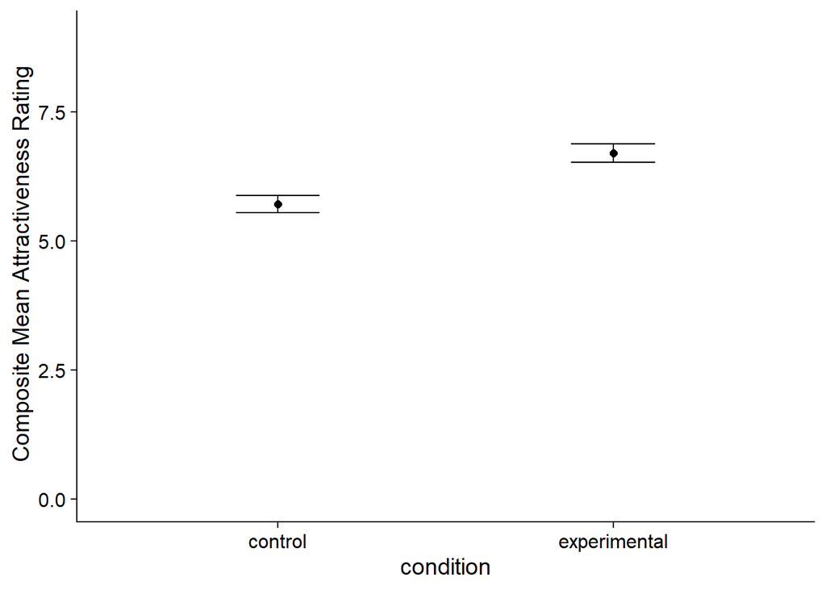

I will now describe and analyse the results from my experiment through the use of a *t*-test. We investigated whether participants would give different ratings of a moderately attractive man depending on the colour condition, using an independent-measures *t*-test. The analysis indicated that, as predicted, the colour white, in the control condition gave a lower mean rating of experience (*M* = 5.71), while in the experimental condition (*M* = 6.7). This difference in means was significant (*M*<sub>diff</sub> = 1), 95% CI [-0.75, -1.25], *t* (127) = -7.91, *p* = 0). From the basic principles of this test, the null hypothesis of the t-test is as follows: the two-sample means originate from the same population (either within the red or white condition), having no effect on the mean composite rating of attractiveness. If this is correct and we accept the null hypothesis, the variance between the two-sample means should be 0. However, as shown by our data, the difference between our two means is not 0, it is 1.0, on our scale of 1-9. In analysis, our evaluation looks to contrast the difference between the mean values we gathered - (also known as the signal), to the standard deviation of the differences between our mean values - (also known as the noise). This aims to generate our t-test to assess the significance of our results. With regards to this test, a greater t-value indicates a reduced chance that the null hypothesis is true, emphasising a stronger signal compared to the noise. Within our data, our value for t is -7.91. The calculated difference between our sample condition means was 1.0. This was 7.91 times greater than the standard error of the difference in means. Therefore, it is very unlikely that our value will arise if the true difference in means is 0 at p < .001. As a result, it is unlikely that these sample means come from the same population - suggesting the null hypothesis may be false and we can accept the alternative. We can therefore conclude that there was a significant difference in the mean attractiveness ratings between the red and white condition groups. In summary, the outcomes of our analysis suggest that the ratings of attractiveness were significantly different between the two conditions. This indicates that red did increase the perceived attractiveness rating of the man.

# Discussion

Our aim from this investigation was to test the association between the colour red and the mean rating of attractiveness of a moderately attractive man, based on the ‘red effect’ reported by Elliot et al (Elliot, et al., 2010). Based on their original findings, women perceived men as being more attractive when in association with red. We followed their procedure to replicate this paradigm, to see whether our outcomes correlated. The statistical results of my experiment indicated that this proposed ‘red effect’ was in fact significant, demonstrating how the colour red does increase perceived attractiveness. As my results delivered the same outcome as the original study, it suggests that there is an evident ‘red effect’ established as both provided significant results. However, it’s arguable that this interpretation is limited. As so, when assessing the reliability of this study, we must correlate the results obtained with a wider field of replicated evidence. In general, replications indicated that there was no true ‘red effect’ discovered. Evidently, later research by Hesslinger et al, provide a close replication of the original study, proving to dispute the outcomes, as there was no true ‘red effect’, reducing the validity of the results (Hesslinger, et al. 2015). Work by Francis (2013) indicates a high level of contradiction, where it was proposed that the original study may have been contaminated with publication bias. This is when statistically significant positive findings have a greater chance of being published (Francis, 2013). This triggered the response for another replication, this time by Elliot and Maier (2013), where they also found no significant effect between red and rated attractiveness (Elliot, & Maier, 2013). Therefore, with the large field of replications disputing the results from both Elliot et al’s original study and my replication, it signifies that there is more evidence against the research than for it, suggesting that the ‘red effect’ has very little impact. Research by Hesslinger et al later proposed that his replication suggested that other factors were more important in determining perceived attractiveness. They reported that the significance of apparel style was more important than the association with a colour. This has been proved the case, as their second experiment found that a higher rating of attractiveness was correlated with a formal style than a casual one (Hesslinger, et al. 2015). Therefore, based on the evidence shown above, I believe the ‘red effect’ is not significant as with repeated replications, no true ‘red effect’ has been found. This is the case as there is a large sum of evidence disputing this effect, undermining both the reliability and validity of results of the original study.

To assess the usefulness of my investigation, I will now discuss the potential limitations which may have produced these issues. When looking into the potential limitations of this investigation, it’s clear that cultural variations within this design were not truly appreciated, making it difficult to generalise across cultures. Despite the attempts Elliot et al did to control this - where they assessed the ‘red effect’ across 4 different countries (Elliot, et al., 2010), it still lacks a holistic image of the variations between cultural views on colour associations. Research has supported this idea, showing how the context-dependent effects, such as societal views on the associations with colour vary culture to culture. This is a key idea which Elliot et al failed to fully appreciate. As so, within countries like China and India, red symbolises pure love, happiness and good fortune. Whereas, in the western culture, white symbolises these key associations instead (Peperkoorn et al. 2016). Thus, this poses as a challenge to the generalisation of my results, meaning we are unable to comment upon the cultural variations, reducing the external validity. A further challenge impacting the control of my investigation are the individual participant variables. These are extraneous variables such as the participants concentration, stress and mood – which can have a major impact on the replication of results. If the participant had a low concentration or tiredness when reporting the attractivity of the male, they are less likely to pay attention to the colour influence, and therefore report a different set of results. This impacts the participants reactivity within the investigation, limiting our ability to comment on individual differences on our data set - as such a variance is almost impossible to completely control. In addition, the sample ages included were only between 18-27, meaning the effects may not be the same for different ages - and is not generalisable. Therefore, based on this analysis, I believe that this proposed ‘red effect’ has not been supported to a degree where we can say the effect is real. Consequently, it may be more effective interpreting other influences which may affect the rating of attractiveness. Future studies may want to assess the potential influence of apparel style like the one developed by Hesslinger, et al. 2015, to investigate an actual effect on perceived rating of attractiveness. I have come to this conclusion as the replications of Elliot et al’s study have provided minimal supporting evidence - and therefore the later research on apparel style has indicated an actual relationship with a cause and effect (Hesslinger, et al. 2015).

Overall, based on my findings and the other research evidence discussed above, I believe that there is no significant ‘red effect’. As a result, we can learn that the basis of the original study was heavily influenced by investigator bias and perhaps a Type 1 error - as proposed by Francis, limiting the validity of the results (Francis, 2013). However, we cannot learn how individual differences may have impacted my results - as these have not been properly counted for. Therefore, overall, I believe that there is no true ‘red effect’ as the replications of the study prove to show no significant relationship. As so, I believe my results don’t show the true results of the ‘red effect’ and instead the null should be accepted rather than rejected.

# References

Elliot, A. J., Niesta Kayser, D., Greitemeyer, T., Lichtenfeld, S., Gramzow, R. H., Maier, M. A., & Liu, H. (2010). Red, rank, and romance in women viewing men. *Journal of Experimental Psychology: General, 139*(3), 399.

Francis, G. (2013). Publication bias in “Red, rank, and romance in women viewing men,” by Elliot et al.(2010).

Elliot, A. J., & Maier, M. A. (2013). The red-attractiveness effect, applying the Ioannidis and Trikalinos (2007b) test, and the broader scientific context: A reply to Francis (2013).

Hesslinger, V. M., Goldbach, L., & Carbon, C. C. (2015). Men in red: A reexamination of the red-attractiveness effect. *Psychonomic bulletin & review, 22*(4), 1142-1148.

Peperkoorn, L. S., Roberts, S. C., & Pollet, T. V. (2016). Revisiting the red effect on

attractiveness and sexual receptivity: No effect of the color red on human mate preferences. *Evolutionary Psychology, 14*(4), 1474704916673841.